# **Evolution of Diet and Physiological Adaptations Across Time**

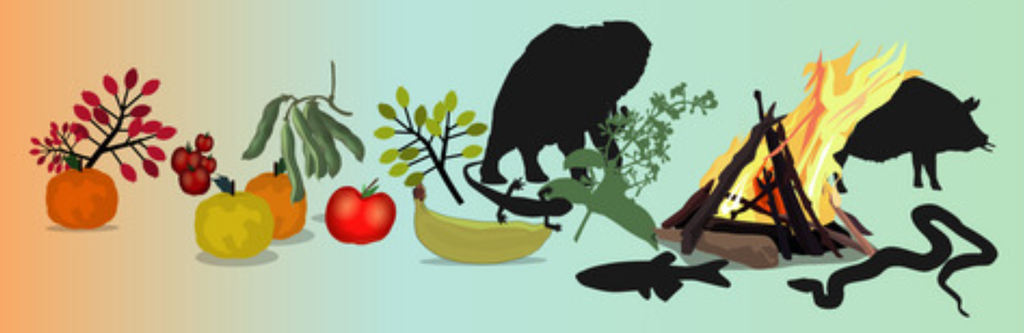

Since the emergence of early human species, dietary preferences have shifted over millions of years alongside significant physiological changes that were observed across species within the Homo genus.

In this infographic, we explore the pivotal role of diet in shaping human evolution, examining how dietary shifts influenced the development of distinct physical traits amongst species.

## How diet patterns have changed over time?

Dietary preferences have evolved over time, with different diet types becoming more prominent in evolutionary history.

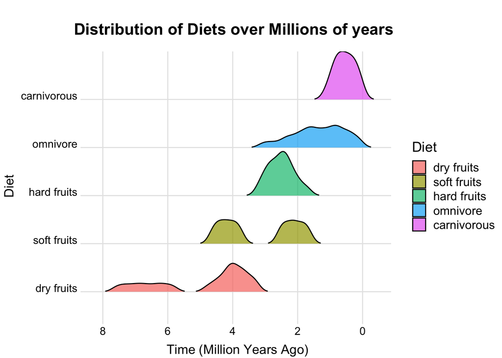

As time progressed, omnivorous and carnivorous diets became more common, indicating an evolutionary trend toward more generalised and meat-based diets in later species. The carnivorous diet appears most prominently around 1 million years ago.

## How have dietary habits influenced limb evolution?

As dietary patterns diversified over time, limb adaptations evolved to support specialised functions. Arms primarily developed for two purposes: climbing and manipulation - (which could include usage of tools for hunting, cooking, foraging, etc). Similarly, feet adaptations evolved along two distinct paths: one specialised for climbing and the other for walking.

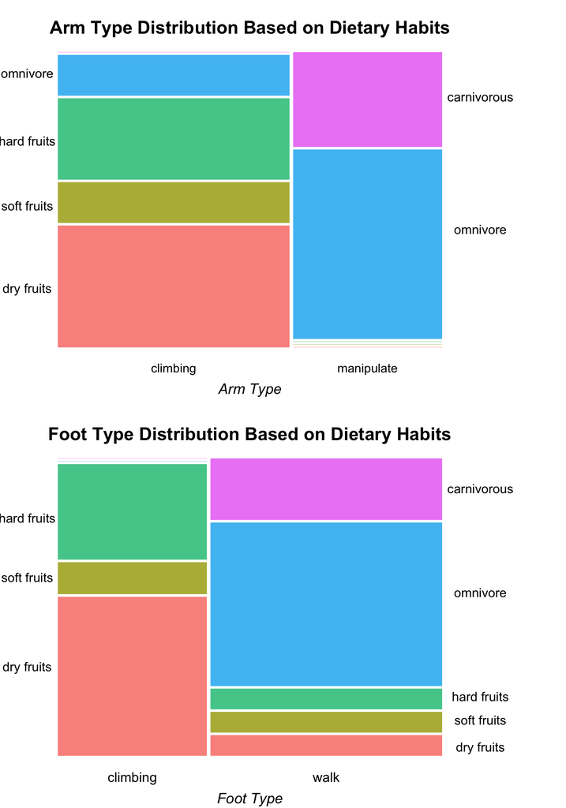

Species that consumed fruit-based diets composed of dry, soft, or hard fruits had a tendency to possess arms and feet adapted for climbing, enhancing their accessibility to fruit in high trees or other similarly difficult settings.

Conversely, carnivorous or omnivorous species based on meat diets had arms suited for manipulation and feet specialised for walking which supported effective hunting with tool adaptation.

Thus, it is clear that dietary habits have incentivised different evolutionary pathways of arm and feet adaptation to improve survival strategies required for specific diet types.

## How have diets shaped tool usage and cranial capacity?

As diet requirements evolved to become more complex, the need for tool usage increased. The advancement of tool usage and the development of cranial capacity appear to have mutually reinforced each other’s development, further accelerating evolutionary changes.

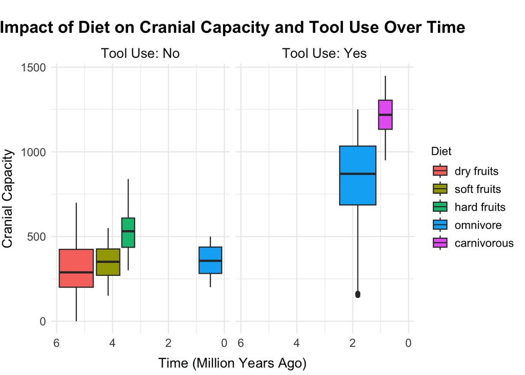

Furthermore, the notable trend of increasing cranial capacity was observed in alignment with a specific order of emerging diets.

These findings support the idea that diet influenced both cranial capacity and the development of tool use, which in turn appear to have further accelerated the other’s development. Conclusively, cranial capacity may have increased due to complex behaviours such as tool use, particularly among species with protein-rich diets.

## **How have diets impacted tooth enamel thickness levels?**

Teeth play a significant role in food intake by supporting the process of biting and chewing food. The thickness of tooth’s enamel, the hard outer layer of the teeth, helps protect it against wear and damage from various food textures. Different types of food have varying levels of intensity and texture, influencing functional demands on teeth, which can be observed through the level of tooth enamel thickness.

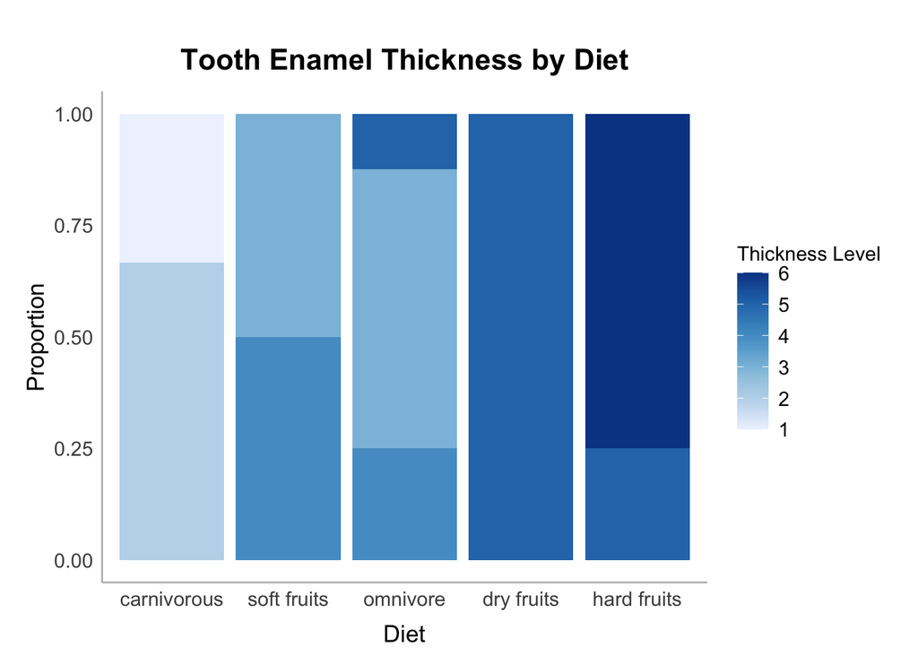

The carnivorous species exhibited the thinnest enamel. Similarly, species that consumed soft fruits had thin enamel due to its soft texture, enabling easy biting and chewing.

The tooth enamel with an omnivorous diet consists of a mixture of thickness levels, intuitively emphasising the fact that omnivorous diets are mixed and result in a similarly mixed demand of teeth functions.

In contrast, the species that intake dry and hard fruit had thick enamel. The tooth enamel was notably thick when the main diet was hard fruit, supporting the functional adaptation of teeth to food of tougher texture.

Thus, it can be seen that diet indeed impacts the development of the thickness level of teeth enamel according to the functional needs of each primary diet.

## How did diets drive the evolution of canine teeth shapes?

Previously, it was shown that teeth evolved in response to functional adaptation across various diet types. Similarly, the canine teeth, whose role is primarily to grasp, tear, and process food, have also changed to reflect the functional needs of the primary diet type.

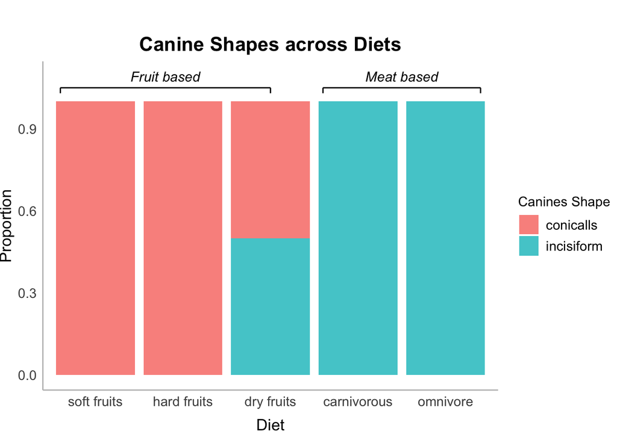

In contrast, carnivorous or omnivorous species with a meat-based diet exhibited incisiform canine shaped teeth. Incisiform canines are flatter and broader than conical shapes. This enhances the teeth’s cutting and slicing functionality often required when processing tough meat.

These findings support the theory that canine shapes have evolved to meet functional needs associated with primary diet types.

## **How have diets influenced the evolution of jaw shapes?**

The intensity of biting and the method of food consumption vary across different diets, influencing the development of jaw structure. This relationship can be observed in the distribution of dietary compositions associated with different jaw shapes.

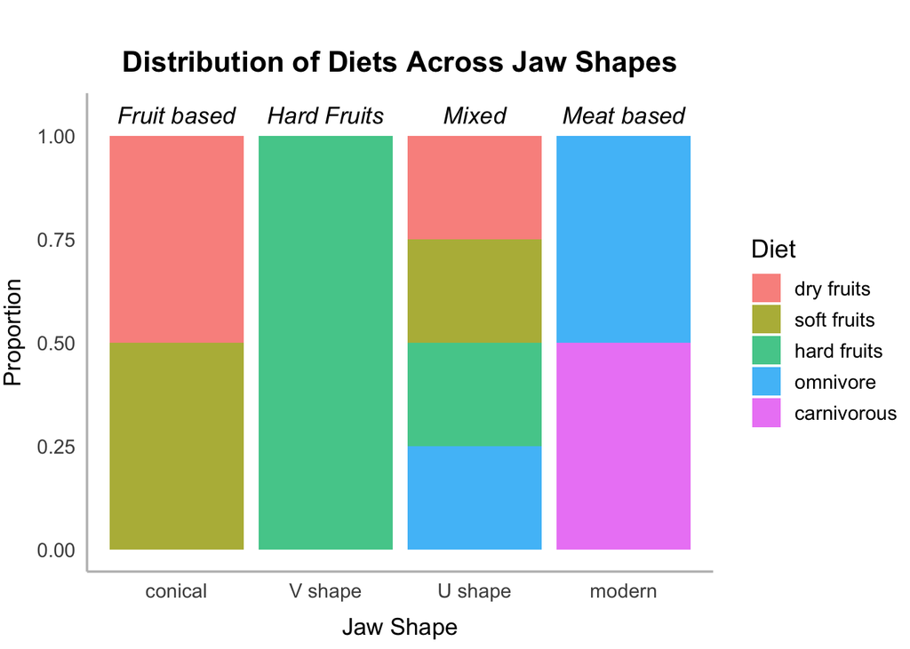

Jaw shapes evolved as adaptations of the variations in diet types such as fruit-based and meat-based diets.

Species with fruit-based diets, including soft and dry fruits, predominantly exhibited conical jaw shapes in response to demands of less forceful but repetitive biting. The light weight of conical jaws enabled quick and repetitive biting needed for consuming soft and dry fruits with precision.

Species focused on hard fruit had a V-shaped jaw, which provides a more robust biting structure. This structure supported the consumption of hard fruit when cracking and breaking hard shells.

Species with a mixed diet, including fruits and meats, exhibit a U-shaped jaw. This shape provides versatility, accommodating both grinding for plant material and tearing or biting for meats.

Carnivorous and omnivorous species with a meat-based diet typically have a “modern” jaw shape, which is robust and capable of delivering high bite force. This shape supports the demands of tearing through flesh or crushing bones.

These findings also demonstrate how jaw shapes have evolved to meet the demands of different diets.

## **The pivotal role of diet in shaping human evolution over time**

As dietary patterns shifted from primarily fruit-based to meat-based diets, various physical adaptations emerged based on functional demands of consuming these primary diets.

Species with a fruit-based diet developed arms and feet adapted for climbing without usage of tools. In contrast, species with a meat-based diet required arms specialised for manipulation - facilitating tool use, and feet adapted for walking and supporting hunting activities.

Additionally, critical functional structures such as teeth and jaws evolved to meet the demands of specific dietary needs. Tooth enamel thickness, canine shapes, and jaw structures varied according to their functional roles. These evolutionary progressions underscore the strong connection between dietary habits and physical adaptations.